# A primer on computational analysis for scRNA-seq data

### Feature selection

```r
seur_obj <- FindVariableFeatures(seur_obj, selection.method = "vst", nfeatures = 2000)
# Identify the 10 most highly variable genes
top10 <- head(VariableFeatures(seur_obj), 5)

# plot variable features with and without labels
plot1 <- VariableFeaturePlot(seur_obj)
plot2 <- LabelPoints(plot = plot1, points = top10, repel = TRUE)
```

```
When using repel, set xnudge and ynudge to 0 for optimal results
```

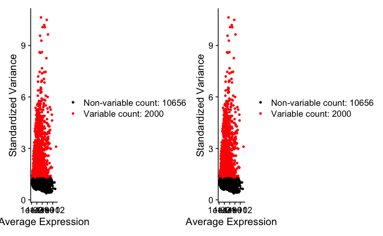

```r
plot1 + plot2
```

### Dimensionality reduction

PCA and heatmaps do usally prefer to have scaled data, we can do it by calling

```r
# Note that here by default we are scaling just the most variable genes, cause it is faster
seur_obj <- ScaleData(seur_obj)
```

To perform the actual PCA

```r
seur_obj <- RunPCA(seur_obj, features = VariableFeatures(object = seur_obj))
```

```
PC_ 1
Positive:  GPNMB, CTSL, CTSB, CYP27A1, MARCO, ADAM9, SOAT1, IFI30, DAB2, CTSD
       CSTB, MSR1, SLCO2B1, GRN, APOC1, ABCG1, MAFB, CXCL3, ACP5, GLUL
       TGM2, TUBA1C, CREG1, LHFPL2, SEMA3C, SCD, PSAP, CTSA, HEXB, NPC2
Negative:  PLA2G1B, PRSS1, CELA3A, CTRB1, CLPS, CPA1, CELA3B, PNLIP, CPB1, REG1A
       CPA2, CTRC, CEL, CTRB2, CELA2A, GP2, SYCN, CELA2B, AMY2A, PRSS3
       IL32, KLK1, AMY2B, PNLIPRP1, IGFBP2, CUZD1, PTPRCAP, SPINK1, CTRL, CD3D
PC_ 2
Positive:  CLPS, CELA3A, CTRB1, CELA3B, CPA2, CPB1, CTRC, CPA1, SPINK1, PRSS1
       PLA2G1B, GP2, REG1A, PNLIP, CELA2A, CEL, SYCN, CTRB2, CELA2B, AMY2A
       PRSS3, KLK1, AMY2B, PNLIPRP1, IGFBP2, CUZD1, FTL, CTRL, ERP27, GATM
Negative:  PTPRCAP, CD2, ETS1, LCK, CD3E, IFITM1, GZMA, CD7, CD247, CD3D
       EVL, CD3G, SKAP1, CD96, CRIP1, ARL4C, CCL5, SPOCK2, GIMAP7, GZMM
       ITM2A, SAMD3, APOBEC3G, CST7, CTSW, LBH, PRF1, IL2RB, RP11-94L15.2, PYHIN1
PC_ 3
Positive:  SPINK1, PRSS3, PRSS1, CLPS, GP2, CTRB1, CEL, CELA3B, REG1A, CTRC
       CPA2, CELA3A, CTRB2, PNLIP, CPA1, CPB1, SYCN, CELA2A, CELA2B, AMY2A
       PLA2G1B, IGFBP2, KLK1, AMY2B, PNLIPRP1, CUZD1, NUCB2, CTRL, GATM, NUPR1
Negative:  S100A9, S100A8, LYZ, MNDA, FCN1, COTL1, LST1, ACTB, FGL2, MS4A6A
       CD74, MPEG1, CYBB, S100A4, HLA-DRA, S100A12, CLEC12A, CFP, HLA-DPA1, AMICA1
       CPVL, POU2F2, IGSF6, FPR1, LILRB2, TNFSF13B, HLA-DPB1, DUSP6, C10orf54, HLA-DRB1
PC_ 4
Positive:  HIF1A-AS2, NDRG1, ERO1L, RP11-841O20.2, HILPDA, ZNF395, HK2, VEGFA, GBE1, MXI1
       SNAPC1, C15orf48, IL8, SLC25A37, G0S2, AK4, FLT1, FCGR2B, EGLN3, CTB-138E5.1
       CD109, RP11-268J15.5, EFNA5, FAM13A, IL1RN, ENO2, CLEC2B, FBP1, DNAH11, MET
Negative:  C1QC, C1QB, TMEM37, C1QA, CCL18, GAL3ST4, SDC3, KCNMA1, APOE, SLC7A8
       SLCO2B1, RMDN3, CABLES1, FRMD4A, CTSC, FUCA1, SIGLEC1, LGMN, ACP2, RAB42
       GCHFR, NUPR1, OLFML2B, SCCPDH, APOC1, CES1, MERTK, LGALS3BP, PLTP, MRO
PC_ 5
Positive:  GZMA, NKG7, MAF, PTPRCAP, IL32, CCL5, CD247, GPNMB, CD7, CTSW
       CD2, GYPC, CD3E, GZMM, NUPR1, PRF1, CTSL, CD3D, IL2RB, SAMD3
       SKAP1, PPAP2B, CD96, SCD, SOAT1, MSR1, CD3G, AC092580.4, ABCG1, PYHIN1
Negative:  C19orf33, KRT19, KLF5, SCNN1A, TFF2, ASAP2, TFF3, S100A16, TFF1, GPRC5A
       PSCA, ELF3, AGR2, CAMK2N1, S100A2, PKIB, ITGB4, TRNP1, LMO7, S100A14
       ITGA2, PTPRH, VSIG2, FHL2, PLEK2, CAPN8, FXYD3, CLDN4, SH3D19, S100P
```

There are different ways of visualizing PCA load ing

```r
# Just print them
print(seur_obj[["pca"]], dims = 1:5, nfeatures = 5)
```

```
PC_ 1
Positive:  GPNMB, CTSL, CTSB, CYP27A1, MARCO
Negative:  PLA2G1B, PRSS1, CELA3A, CTRB1, CLPS
PC_ 2
Positive:  CLPS, CELA3A, CTRB1, CELA3B, CPA2
Negative:  PTPRCAP, CD2, ETS1, LCK, CD3E
PC_ 3
Positive:  SPINK1, PRSS3, PRSS1, CLPS, GP2
Negative:  S100A9, S100A8, LYZ, MNDA, FCN1
PC_ 4
Positive:  HIF1A-AS2, NDRG1, ERO1L, RP11-841O20.2, HILPDA
Negative:  C1QC, C1QB, TMEM37, C1QA, CCL18
PC_ 5
Positive:  GZMA, NKG7, MAF, PTPRCAP, IL32
Negative:  C19orf33, KRT19, KLF5, SCNN1A, TFF2
```

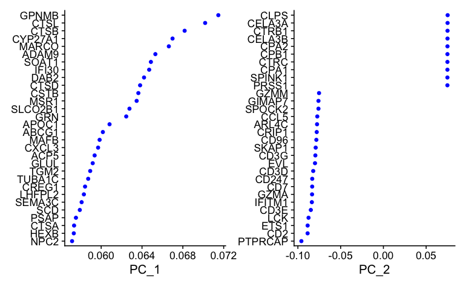

```r
# Or a plot of this type
VizDimLoadings(seur_obj, dims = 1:2, reduction = "pca")
```

You can still see some division in the cells in the first two dimensions

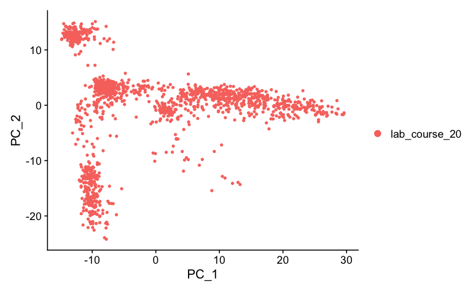

We can visualize the top markers in our dataset with an heatmap

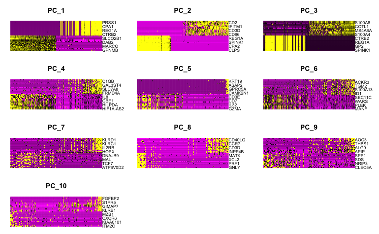

A classical way of selecting the optimal number of dimensions is to look at an elbow point in the variance explained by each component

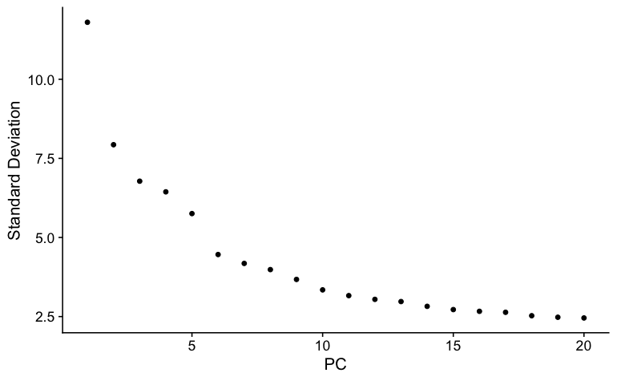

### Cell cycle regression

```
The following requested variables were not found: TOP2A, MKI67
```

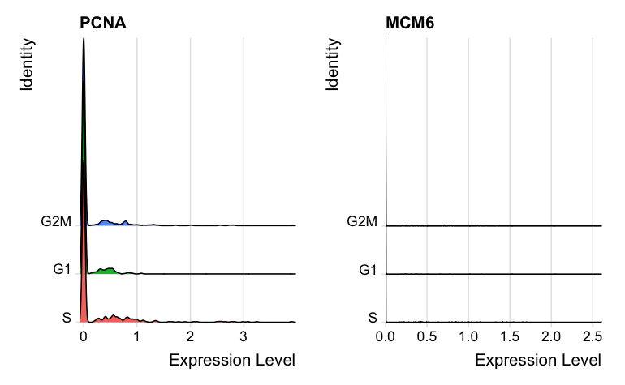

```r
RidgePlot(seur_obj, features = c("PCNA", "TOP2A", "MCM6", "MKI67"), ncol = 2)
```

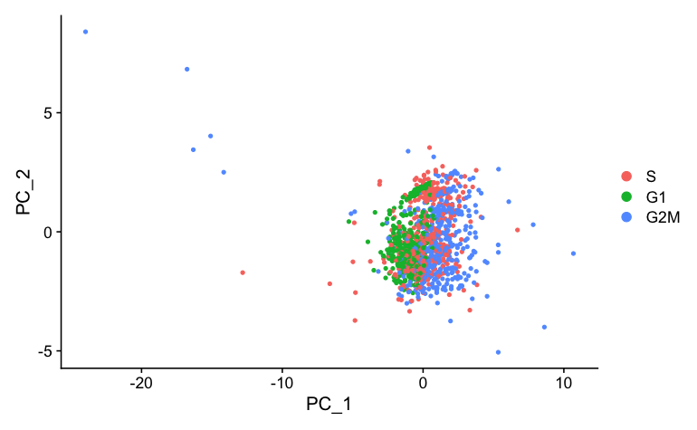

[figure not shown]

#### Alternative way

Sometimes regress out the effects of cell cycle can affect in a negative way downstream analysis. So a milder way of correcting the dataset can be by regressing against the difference of S phase score and G2 score. In this way we eliminate the difference within proliferating cells, but mantainint the distiction with non-proliferating ones.

```r
seur_obj_old$CC.Difference <- seur_obj_old$S.Score - seur_obj_old$G2M.Score
seur_obj_old <- ScaleData(seur_obj_old, vars.to.regress = "CC.Difference", features = rownames(seur_obj_old))

seur_obj_old <- RunPCA(seur_obj_old, features = c(s.genes, g2m.genes))

DimPlot(seur_obj_old)
```

[output not shown]

[output not shown]

### Cell clustering

Now that you are more expert about clustering methods I can explain the algorithm sorically used by Seurat: -.. First of all calculate a KNN graph in PCA space, usally with Euclidean distance -.. Then you refine the distance based on how many neighbourds are shared by two points (Jaccard distance) -.. In the end we use the Louvain algorithm to cluster the data (optimizing modularity)

In 2019 a new version of the Louvain algorithm called Leiden algorithm was published on Scientific Reports, which improves over the connectivity of the clusters. This is the standard now in Scanpy and Seurat.

Now let’s do it in practice

```r
# Build the KNN graph
seur_obj <- FindNeighbors(seur_obj, dims = 1:PCs)
```

[output not shown]

### Non linear dimensionality reduction

To visualize our cluster let’s perform some dimensionality reduction, let’s start with UMAP and T-SNE

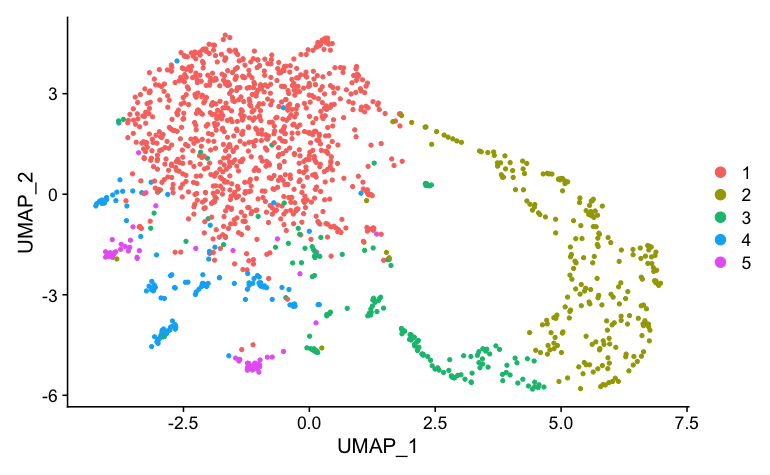

```r
seur_obj <- RunUMAP(seur_obj, dims = 1:PCs)
DimPlot(seur_obj, reduction = "umap")
```

We can do the exact same process for T-sne

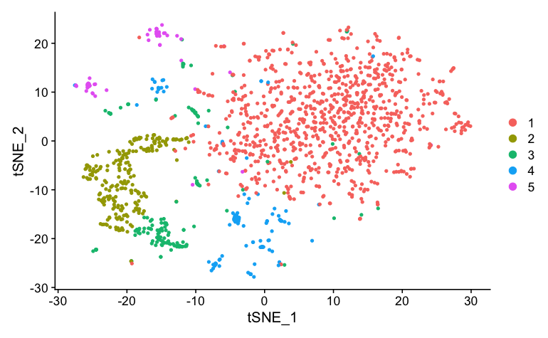

```r
seur_obj <- RunTSNE(seur_obj, dims = 1:PCs)

DimPlot(seur_obj, reduction = "tsne")
```

Unfortunately diffusion maps are not implemmented by default in Seurat, we are going to calculate them for our dataset using the destiny package and the integrate the new measurement in our Seurat object

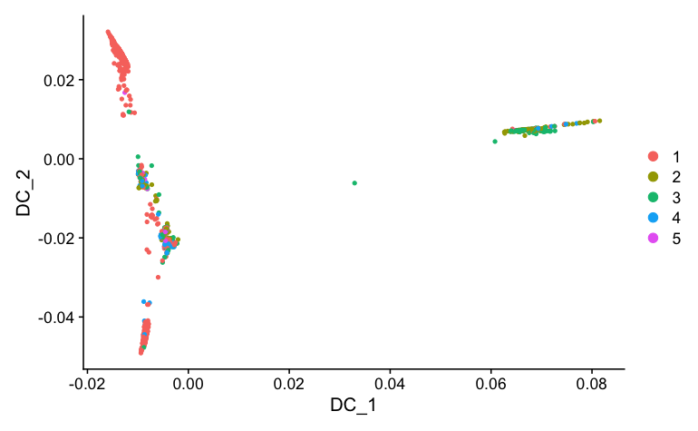

```r
library(destiny)

df_map <-  DiffusionMap(as.SingleCellExperiment(seur_obj), n_pcs = PCs)


seur_obj[["dm"]] <- CreateDimReducObject(embeddings = df_map@eigenvectors, key="DC_", assay=DefaultAssay(seur_obj))


DimPlot(seur_obj, reduction = "dm")
```

### Cell type identification

A good first idea is to look at some marker genes for our Leiden clusters

```r
seur_obj_markers <- FindAllMarkers(seur_obj, only.pos = TRUE, min.pct = 0.25, logfc.threshold = 0.25, test.use = "roc")
```

[output not shown]

[output cut: 45 more lines]

[output not shown]

[output not shown]

[output cut: 39 more lines]

[output not shown]

[output not shown]

[output cut: 45 more lines]

[output not shown]

[output not shown]

[output cut: 35 more lines]

[output not shown]

[output not shown]

[output cut: 43 more lines]

[output not shown]